# Homework Assignment One

Jonathan Bonaguro

February 23, 2020

## For the following homework, you can use the lecture slides, hands-on-notebooks, reference books, google search, and `?` in R console as resources for help.

### Problem 1

1. (1 Point) What type of vector values are stored in object `a`. `a <- c("1","2","3")`. Go ahead and convert them to `numeric` type.

```r
a<-c("1","2","3")
typeof(a)
```

```
[1] "character"
```

```r
as.numeric(a)
```

```
[1] 1 2 3
```

### Problem 2

2. (1 Point) In R, the following arthimetic operation `b*2` on the object `b<-c(4,5,5,7)` will result in the following solution `(8,10,10,14)`. Which of the following accurately descibes how R handled this operation:
   1. Arithmetic recyling
   2. **Vector recyling**
   3. Complex substituion
   4. Vector coercion

### Problem 3

3. (2 Points) Let’s say you want to store multiple vector types in a R object `c`. What is wrong with the following code: `c <- c("Good Morning",1,TRUE)`. Can you rewrite this code appropriately?

**`c` automatically concatenates a vector, and vectors have to be data of the same type. The following code records the data as a type `list`**

```r
c <- c(list("Good Morning", 1, TRUE))
c
```

```
[[1]]
[1] "Good Morning"

[[2]]
[1] 1

[[3]]
[1] TRUE
```

### Problem 4

4. (1 Point) Which of the following describes accurately about `class` of a R object?
   1. type
   2. dimension
   3. **Attribute**
   4. None of the above

### Problem 5

5. (1 Point) Which among the following operation will return the entire `mtcars` dataframe (including all rows and colums):
   1. **`mtcars[TRUE,]`**
   2. `mtcars[TRUE,c(FALSE)]`
   3. `mtcars[TRUE,FALSE]`
   4. `mtcars[FALSE,TRUE]`

```r
mtcars[TRUE, ]
```

```
                     mpg cyl  disp  hp drat    wt  qsec vs am gear carb
Mazda RX4           21.0   6 160.0 110 3.90 2.620 16.46  0  1    4    4
Mazda RX4 Wag       21.0   6 160.0 110 3.90 2.875 17.02  0  1    4    4
Datsun 710          22.8   4 108.0  93 3.85 2.320 18.61  1  1    4    1
Hornet 4 Drive      21.4   6 258.0 110 3.08 3.215 19.44  1  0    3    1
Hornet Sportabout   18.7   8 360.0 175 3.15 3.440 17.02  0  0    3    2
Valiant             18.1   6 225.0 105 2.76 3.460 20.22  1  0    3    1
Duster 360          14.3   8 360.0 245 3.21 3.570 15.84  0  0    3    4
Merc 240D           24.4   4 146.7  62 3.69 3.190 20.00  1  0    4    2
Merc 230            22.8   4 140.8  95 3.92 3.150 22.90  1  0    4    2
Merc 280            19.2   6 167.6 123 3.92 3.440 18.30  1  0    4    4
Merc 280C           17.8   6 167.6 123 3.92 3.440 18.90  1  0    4    4
Merc 450SE          16.4   8 275.8 180 3.07 4.070 17.40  0  0    3    3
Merc 450SL          17.3   8 275.8 180 3.07 3.730 17.60  0  0    3    3
Merc 450SLC         15.2   8 275.8 180 3.07 3.780 18.00  0  0    3    3
Cadillac Fleetwood  10.4   8 472.0 205 2.93 5.250 17.98  0  0    3    4
Lincoln Continental 10.4   8 460.0 215 3.00 5.424 17.82  0  0    3    4
Chrysler Imperial   14.7   8 440.0 230 3.23 5.345 17.42  0  0    3    4
Fiat 128            32.4   4  78.7  66 4.08 2.200 19.47  1  1    4    1
Honda Civic         30.4   4  75.7  52 4.93 1.615 18.52  1  1    4    2
Toyota Corolla      33.9   4  71.1  65 4.22 1.835 19.90  1  1    4    1
Toyota Corona       21.5   4 120.1  97 3.70 2.465 20.01  1  0    3    1
Dodge Challenger    15.5   8 318.0 150 2.76 3.520 16.87  0  0    3    2
AMC Javelin         15.2   8 304.0 150 3.15 3.435 17.30  0  0    3    2
Camaro Z28          13.3   8 350.0 245 3.73 3.840 15.41  0  0    3    4
Pontiac Firebird    19.2   8 400.0 175 3.08 3.845 17.05  0  0    3    2
Fiat X1-9           27.3   4  79.0  66 4.08 1.935 18.90  1  1    4    1
Porsche 914-2       26.0   4 120.3  91 4.43 2.140 16.70  0  1    5    2
Lotus Europa        30.4   4  95.1 113 3.77 1.513 16.90  1  1    5    2
Ford Pantera L      15.8   8 351.0 264 4.22 3.170 14.50  0  1    5    4
Ferrari Dino        19.7   6 145.0 175 3.62 2.770 15.50  0  1    5    6
Maserati Bora       15.0   8 301.0 335 3.54 3.570 14.60  0  1    5    8
Volvo 142E          21.4   4 121.0 109 4.11 2.780 18.60  1  1    4    2
```

### Problem 6

6. In the following list `list_a`, which of the following operation will return the value 3?
   1. `sum(list_a[[1]])`
   2. `sum(list_a[[3]])`
   3. `sum(list_a[1])`
   4. **both a and b are true**

### Problem 7

7. (5 points) What will the following combinations of logical and boolean operations return?
   1. `(2<1) & (3<4) & (5<6)` == `FALSE`
   2. `(2<1) | (3<4) | (5<6)` == `TRUE`
   3. `(FALSE<TRUE) & (TRUE>FALSE) & (FALSE!=TRUE)` == `TRUE`
   4. `any(c(2<1 & 3<4 & 5<6),(2<1 | 3<4 | 5<6),(FALSE<TRUE & TRUE>FALSE & FALSE!=TRUE))` == `TRUE`
   5. `all(1%in%c(2,3,4),0%in%c(FALSE,TRUE),1%in%100==100)` == `FALSE`

### Problem 8

8. (2 Points) What is the use of `ifelse()` function? Execute the `ifelse()` function with an example of your choice.

**`ifelse()` exectues a logical test and returns the value of argument `yes=` if `test` returns `TRUE` and returns the value of argument `no=` if `test` returns `FALSE`.**

```r
x <- 1:10
sum(ifelse(x>=0, yes = x, NA))
```

```
[1] 55
```

```r
x <- -2:10
sum(ifelse(x>=0, yes = x, NA))
```

```
[1] NA
```

### Problem 9

9. (1 Point) What is the use of `switch()` function?

**The `switch()` function basically takes the place of nested `else if` loops. It allows us to choose an argument to use based on an input, `EXPR`, which is then matched to defined arguments to determine what should be done.**

### Problem 10

10. (2 Points) What is the role of next and break statements in controling the flow of code? Write an example code of your choice to demonstrate the use of both next and break statements.

**`next` controls the flow by stopping the current iteration and advances the index of the loop. `break` exits a loop and transfer is moved to the next statement outside of the loop.**

```r
for(i in 1:10) {
  if(i == 3) {
    next
  }
  if(i == 9) {
    break
  }
  print(paste("This is the number", i))
}
```

```
[1] "This is the number 1"
[1] "This is the number 2"
[1] "This is the number 4"
[1] "This is the number 5"
[1] "This is the number 6"
[1] "This is the number 7"
[1] "This is the number 8"
```

### Problem 11

11. (2 Points) What is the use of `sample()` function? Execute the `sample()` function with an example of your choice.

**`sample()` is used to take a sample of a size `size=` from an element `x=` (usually a vector)**

```r
set.seed(385)
sample(x = 1:100, size = 50)
```

```
 [1]  6 90 87 82 16 50 86 53 17 92 95 23 78 15 19 43 56  9  1 57 33 10 68 58 73 83 88 76 28
[30] 75 12  5 69 27 40 29 49 81 70 59 11 91 34 89  8 66 63  7 67 14
```

### Problem 12

12. (2 Points) What is the use of `rep()` function? Execute the `rep()` function with an example of your choice.

**The `rep()` function replicates the values in an input vector `x =`. The output can be specified by either `times =` (the number of times to repeat `x`), or `length.out =` (the desired length of the output).**

```r
y <- 1:10
rep(x = y, length.out = 52)
```

```
 [1]  1  2  3  4  5  6  7  8  9 10  1  2  3  4  5  6  7  8  9 10  1  2  3  4  5  6  7  8  9
[30] 10  1  2  3  4  5  6  7  8  9 10  1  2  3  4  5  6  7  8  9 10  1  2
```

```r
rep(x = y, times = 3)
```

```
 [1]  1  2  3  4  5  6  7  8  9 10  1  2  3  4  5  6  7  8  9 10  1  2  3  4  5  6  7  8  9
[30] 10
```

### Problem 13

13. (2 Points) What is the use of `runif()` function? Execute the `runif()` function with an example of your choice.

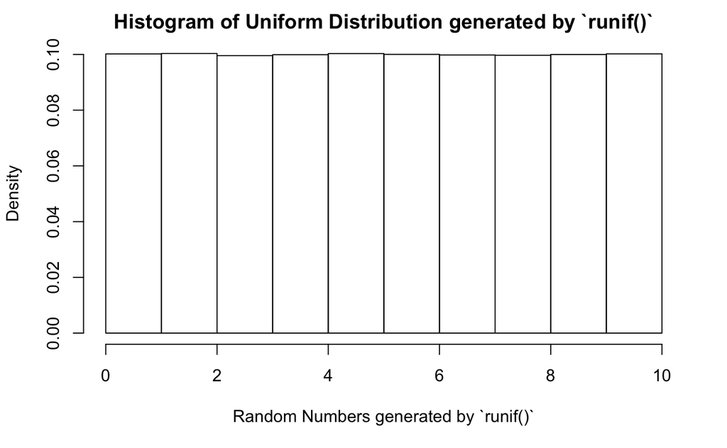

```r
set.seed(385)
random <- runif(1000000, min = 0, max = 10)
hist(random, main = "Histogram of Uniform Distribution generated by `runif()`", probability = TRUE, xlab = "Random Numbers generated by `runif()`", breaks = 10)
```

### Problem 14

14. (2 Points) What is the use of `rnorm()` function? Execute the `rnorm()` function with an example of your choice.

**`rnorm` generates `n` random numbers from a normal distribution specified by `mean =` and `sd =`. To demonstrate normality, I plot a histogram of a `rnorm()` sample from the standard normal distribution.**

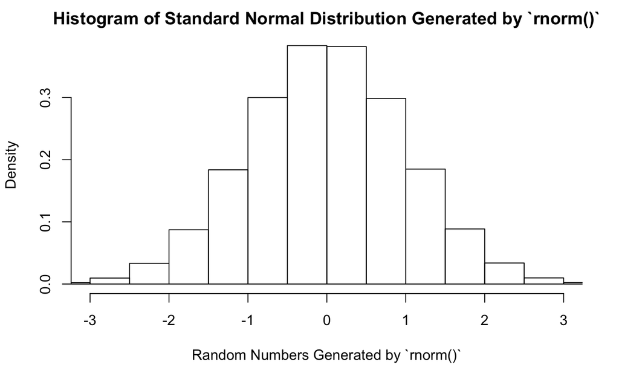

```r
set.seed(385)
random <- rnorm(1000000, mean = 0, sd = 1)
hist(random, main = "Histogram of Standard Normal Distribution Generated by `rnorm()`", probability = TRUE, xlab = "Random Numbers Generated by `rnorm()`", xlim = c(-3, 3))
```